# Data Science Specialization November 2015

## Title

I am interested in examining how the available business data may be analysed and processed with a view to predicting what scores and other sentiments future reviews may have for the same group of businesses, or, all things being equal, other businesses with similar profiles.

## Introduction

The purpose of this report is to provide feedback from my research of the available YELP data with a view to answering a number of questions relating to my interest in predictive analytics (supra), including:

1. whether review prediction is possible
2. whether there were gender or seasonal variations in review results
3. whether sentiment analysis of the reviews will aid prediction

I have attempted to answer these questions and both my mehodology and results are set out below:

## Methods and data

The available YELP dataset is is main data that is being used for this exercise. These are  
essentially data relating to reviews of various businesses, in a variety of locations, conatained in datasets i.e. businesses, users, reviews, check-ins and tips. In terms of volumes, these include, around:

60,000 Businesses,

370,000 Users, and

1.5 million Reviews

As far as gender derivation from name is concerned, I compiled a list of male and female names and their variations and matched these to the names in the user list. I included only those where there was a match and there was no ambiguity e.g. Bobby could be Robert or Roberta etc. I also focused mainly on English names. The main source of gender data was the Complete US Census Bureau names list data, supplemented with Social Security data and data that I had previously comiled and used for other purposes.

For the sake of simplicity, starts of seasons are defined follows: 20 Mar - Spring,

21 Jun - Summer,

23 Sep - Autumn, and

21 Dec - Winter

Turning to sentiment analysis, in an attempt to extract, identify and characterise the sentiment content of reviews submitted, I compiled a lexicon of positive, negative and neutral words expressing sentiment and then matched these against the text contained in the reviews. Finally, I compared the results with other review responses including e.g. stars to explore deviations in expected correlations. The words contained in my lexicon included words extracted from the lexicon produced by Bing Liu (UIC) as well as the Harvard Inquirer Dictionary.

## Results

To begin with, there are seasonal variations, with the most review being submitted in Summer. This is significantly more than the other three seasons. Winter show a slight reduction.

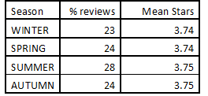

# As a simple barchart, this appears as follows:

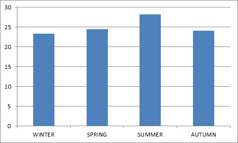

What is apparent, is that there is little difference in the reviews (stars)

Looking at this more closely, we add Gender into the mix.

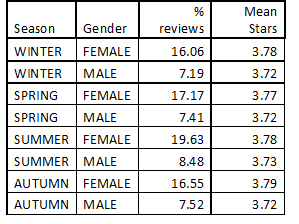

From this, it is clear that females apppear to be more active in posting reviews. However, once again, the average values do not show marked differences.

Looking at sentiment, this correlated well in many cases to the stars. People who have a negative experice are often more troubled by this than the converse with people having a positive experience e.g.

“I wish I could choose no stars. This is one of the worst….”

“DO NOT GO HERE IF YOU HAVE YOUNG KIDS..”

“This place is horrible”

“HORRIBLE service”

There are many situations however, where the review and star ratings conflict. Take for example:

“..A great deal! … they were tasty. A pretty good experience”,

“Good experience” and

“I would definitely come back again”

and contrast these with:

“Quality has degraded”,

“Ugh”, and

“AWFUL EMPLOYEES”

All of the above, good and bad, are rated as three stars and you could find simlar comments up and down the scale.

If we examine this more closely, starting with negative sentiment, then the % of each of the star rating categories is represented by negative reviews as follows:

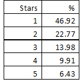

or visually, it looks like this

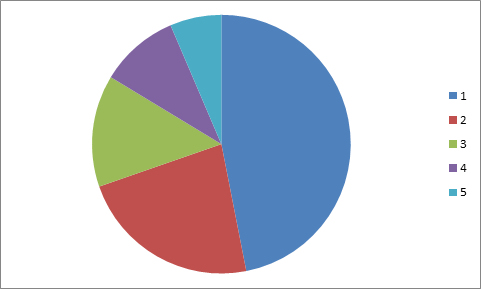

While you would expect the numbers to be closely correlated to the 1 and 2 star ratings, it is nevertheless surprising that there are so many reviews that seem to conflict with the star ratings.

The same is true of positive ratings:

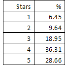

and once again, visually, it looks like this

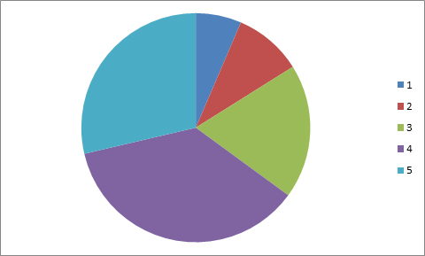

Here the vales for 4 and 5 stars are what you would expect. However, the results lower down are again surprising.

This illustrates perfectly the danger of relying on a single star score in isolation, as many of us do. Clearly, there must be a more accurate way of collecting better data, perhaps by rating a number of areas e.g. in a restaurant, this could include food, service, ambiance etc., with each being weighted appropriately if required, before arriving at a single score, it that is what is being aimed for.

## Discussion

At the outset, it should be stated that reviews are more subjective than objective and as such, the reviews and scores etc. may not be statistically valid. Nevertheless, they are opinions and are valid as such. The study by Harvard Business School showed that in relation to Yelp, an increase of one star in translated to an increase in revenue of between 5 and 9%. c.f Reviews, Reputation and Revenue: The case of Yelp.com, by Professor Michael Luca.

It appears that across the board, women appear to dominate in terms of submission of reviews, while there appears to be no difference between the average ratings given by men and women. Nevertheless, the average ratings are rather higher than one might expect. When you post a review on Yelp, you cannot help notice the previous reviews and the questions, “Do these reviews affect your score / post?”. In this world of social media, there appears to be a desire to gravitate collectively to positive social influence i.e. a social influence bias.

Since negative experiences involve more thinking about, this sentiment is often expressed in stronger terms, than positive experiences. There is also some evidence that younger people tend to write more negative reviews. The amount of money being spent and the expectation that follows, are also relevant.

In terms of predicting review scores, all the above are significant, but more important and lacking here, are all the data required to support the prediction process. Typically, these will include age, income and levels of education etc. Some generalised profiling data are available (at a price) that may fill in some of the gaps, but persuading the reviewers to provide honest and accurate demographic data may be difficult. A survey may be the way forward.

Nevertheless, in our modern society, Yelp and the like play an important part in many businesses turnover and members of the public increasingly rely on review to may purchasing decisions. Ultimately, more data need to be collected to be able to produce a model for predicting futiure review scores and content. At the end of the day, there are two main purposes for these reviews a) the business who can choose to treat the reviews as feedback to be acted upon if necessary, and b) members of the public who use the reviews as a guide to making a purchase.

In conclusion, it has been seen that predicting scores from reviews is fraught with problems. The value that one person assigns to a review may be different to another. In addition there is also the question of whether or not there is any significance to the influence of other reviewers postings. As far as seasonal variations are concerned, the only discernible difference is that there are more postings in Summer and slightly less in Winter. This is what we would expect. Interestingly, women appear to post more than men, but in both the case of gender and seasons, there appear to be no difference in the reviews and scores being posted.